# 4.3 Exercise: random intercepts and slopes

# Predictions / credible intervals

Again, we can generate predictions and compute credible intervals (for the deterministic part of the model). Here: 90% credible intervals.

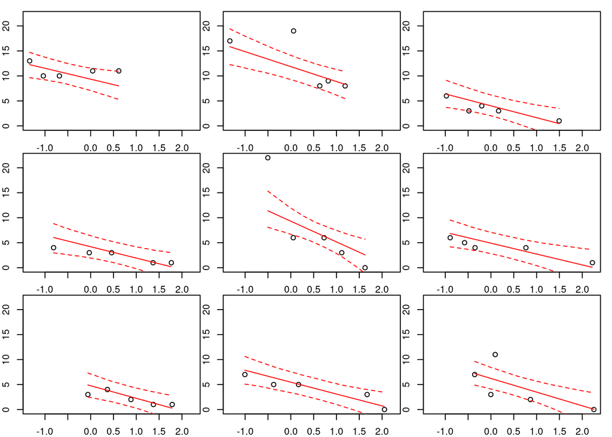

```r
posterior=as.matrix(fit_partpool)

par(mfrow=c(3,3), mar=c(1,1,1,1), oma=c(1,1,0,0))
for (i in 1:9){
  df.sub=subset(df, df$Beach==i)
  x.pred = seq(from=min(df.sub$NAP), to=max(df.sub$NAP), by=0.01)
  plot(df.sub$NAP,  df.sub$Richness,
       xlim=range(df$NAP),
       ylim=range(df$Richness)  )

  y.cred = matrix(0, nrow=nrow(posterior), ncol=length(x.pred))
  for(j in 1:nrow(posterior)){
    y.cred[j, ] = posterior[j,paste0("a[",i,"]")] + posterior[j,paste0("b[",i,"]")]*x.pred
  }

  y.cred.mean = apply(y.cred, 2, function(x) mean(x))
  lines(x.pred, y.cred.mean, col="red")

  y.cred.q05 = apply(y.cred, 2, function(x) quantile(x, probs=0.05))
  lines(x.pred, y.cred.q05, col="red", lty=2)

  y.cred.q95 = apply(y.cred, 2, function(x) quantile(x, probs=0.95))
  lines(x.pred, y.cred.q95, col="red", lty=2)
}
```

# brms complete pooling

We start with the “complete pooling” model in `brms`, which fits just a linear regression on `NAP`, ignoring the effect of predictor `Beach` on the intercept and slope. It’s the same complete pooling model as in the random intercepts regression before.

```r
fit.b.compl = brm( Richness ~ NAP,
                   data=df )
```

```r
fit.b.compl
```

```
##  Family: gaussian
##   Links: mu = identity; sigma = identity
## Formula: Richness ~ NAP
##    Data: df (Number of observations: 45)
##   Draws: 4 chains, each with iter = 2000; warmup = 1000; thin = 1;
##          total post-warmup draws = 4000
##
## Population-Level Effects:
##           Estimate Est.Error l-95% CI u-95% CI Rhat Bulk_ESS Tail_ESS
## Intercept     6.64      0.67     5.31     7.94 1.00     3382     2541
## NAP          -2.87      0.64    -4.13    -1.60 1.00     3834     2667
##
## Family Specific Parameters:
##       Estimate Est.Error l-95% CI u-95% CI Rhat Bulk_ESS Tail_ESS
## sigma     4.24      0.46     3.46     5.25 1.00     3193     2526
##
## Draws were sampled using sampling(NUTS). For each parameter, Bulk_ESS
## and Tail_ESS are effective sample size measures, and Rhat is the potential
## scale reduction factor on split chains (at convergence, Rhat = 1).
```

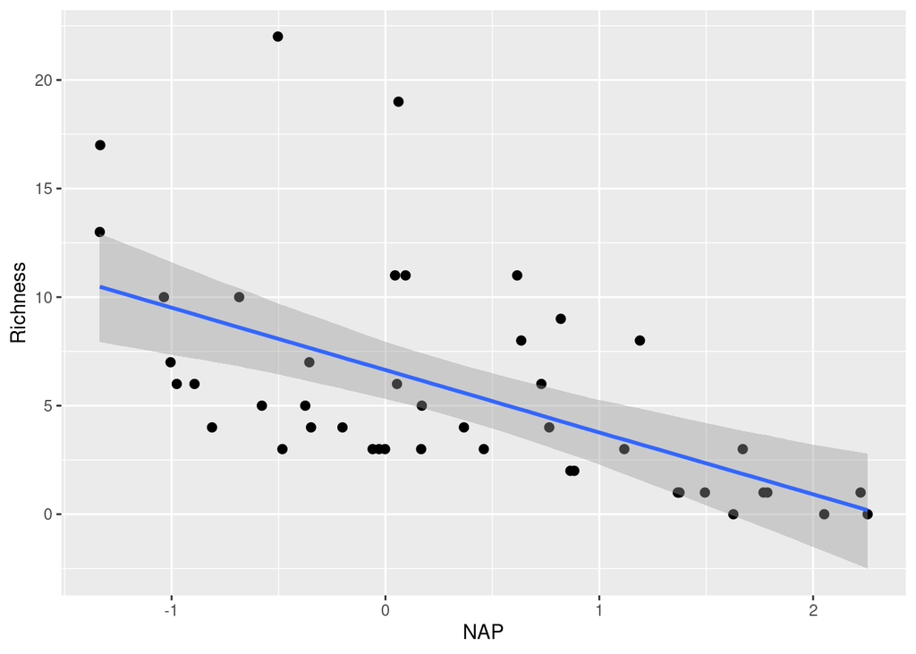

```r
plot( conditional_effects(fit.b.compl),
      points=TRUE,
      ask=FALSE )
```

# brms no pooling

Next, “no pooling” fits different intercepts and slopes for all level of the categorical predictor `Beach`.

But first we must code `Beach` as a factor, otherwise it would be interpreted as a continuous predictor.

```r
str(df)
```

```
## 'data.frame':    45 obs. of  5 variables:
##  $ Sample  : int  1 2 3 4 5 6 7 8 9 10 ...
##  $ Richness: int  11 10 13 11 10 8 9 8 19 17 ...
##  $ Exposure: int  10 10 10 10 10 8 8 8 8 8 ...
##  $ NAP     : num  0.045 -1.036 -1.336 0.616 -0.684 ...
##  $ Beach   : int  1 1 1 1 1 2 2 2 2 2 ...
```

```r
df$Beach = as.factor(df$Beach)
```

```r
fit.b.no = brm( Richness ~ NAP * Beach,
                data=df )
```

As usual with categorical predictors, `lm()` or `brm()` uses dummy coding. I.e. the presented effects are not the different intercepts and slopes for all levels of `Beach`. The intercept for the first level of `Beach` is `Intercept`, but `Beach2` etc are the differences in intercept for the other levels. `NAP` (effect name `b_NAP`) is the slope for the first level of `Beach`, and `NAP:Beach2` etc are the differences in slope for the other levels.

```r
fit.b.no
```

```
##  Family: gaussian
##   Links: mu = identity; sigma = identity
## Formula: Richness ~ NAP * Beach
##    Data: df (Number of observations: 45)
##   Draws: 4 chains, each with iter = 2000; warmup = 1000; thin = 1;
##          total post-warmup draws = 4000
##
## Population-Level Effects:
##            Estimate Est.Error l-95% CI u-95% CI Rhat Bulk_ESS Tail_ESS
## Intercept     10.78      1.42     8.04    13.53 1.00      992     1576
## NAP           -0.39      1.60    -3.53     2.64 1.00      892     1480
## Beach2         2.56      1.85    -1.00     6.12 1.00     1422     2096
## Beach3        -7.38      1.81   -10.90    -3.82 1.00     1385     1888
## Beach4        -7.69      1.96   -11.55    -3.74 1.00     1498     2209
## Beach5         2.00      2.05    -2.07     6.02 1.00     1752     2229
## Beach6        -6.45      1.82   -10.08    -2.92 1.00     1363     2109
## Beach7        -7.22      2.44   -12.03    -2.36 1.00     1821     2228
## Beach8        -5.84      1.91    -9.60    -2.08 1.00     1376     1955
## Beach9        -4.52      1.96    -8.39    -0.55 1.00     1509     2229
## NAP:Beach2    -3.77      2.03    -7.73     0.24 1.00     1290     2174
## NAP:Beach3    -1.37      2.07    -5.34     2.60 1.00     1262     1998
## NAP:Beach4    -0.87      2.00    -4.74     3.11 1.00     1200     2164
## NAP:Beach5    -8.54      2.23   -12.95    -4.14 1.00     1295     2330
## NAP:Beach6    -1.00      1.87    -4.57     2.67 1.00     1118     1930
## NAP:Beach7    -1.17      2.38    -5.78     3.73 1.00     1462     1829
## NAP:Beach8    -1.52      1.87    -5.09     2.16 1.00     1201     1788
## NAP:Beach9    -2.57      2.03    -6.50     1.55 1.00     1321     2150
##
## Family Specific Parameters:
##       Estimate Est.Error l-95% CI u-95% CI Rhat Bulk_ESS Tail_ESS
## sigma     2.57      0.37     1.96     3.42 1.00     1726     1993
##
## Draws were sampled using sampling(NUTS). For each parameter, Bulk_ESS
## and Tail_ESS are effective sample size measures, and Rhat is the potential
## scale reduction factor on split chains (at convergence, Rhat = 1).
```

By using `conditions=` and specifying all levels of `Beach`, effect of `NAP` is shown for all levels. Slope is different in all levels.

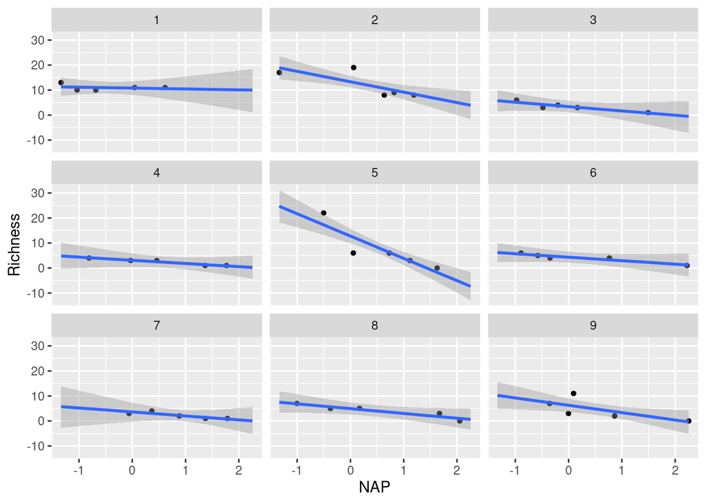

```r
plot( conditional_effects(fit.b.no,
                          effects = "NAP",
                          conditions = data.frame( Beach=levels(df$Beach) ) ),
      points=TRUE,
      ask=FALSE )
```

The group-level predictions can also be extracted by hand using `fitted()`. We can specify the range of `NAP` and levels of `Beach` with `newdata`. We plot 95% credible intervals.

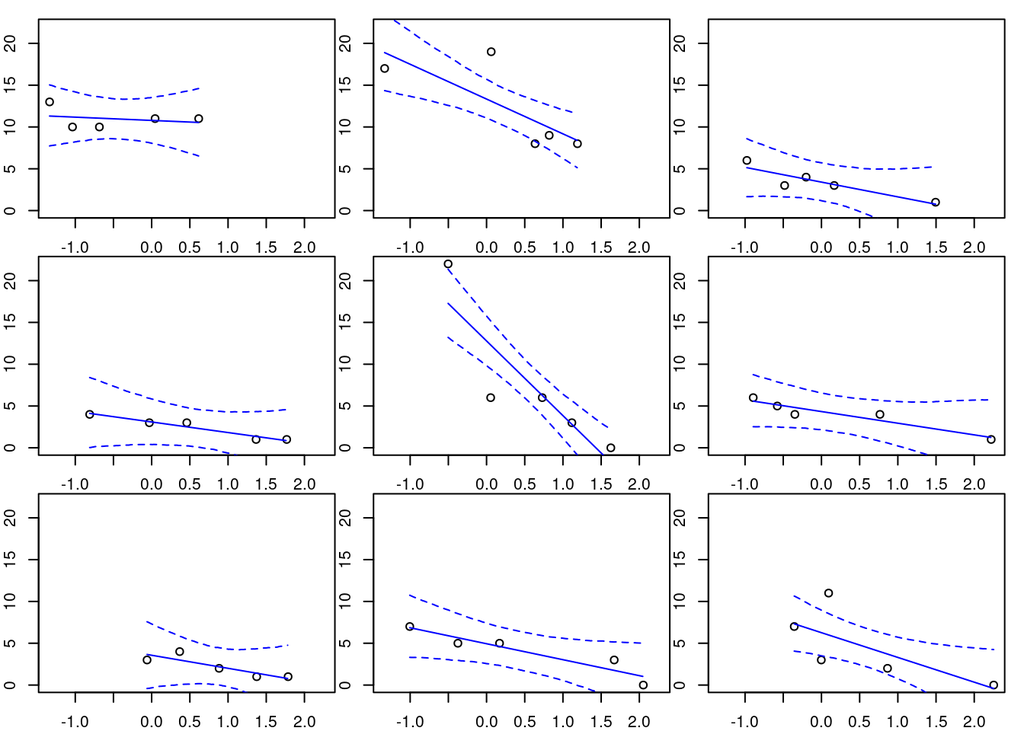

```r
levels = levels(df$Beach)
par(mfrow=c(3,3), mar=c(1,1,1,1), oma=c(1,1,0,0))

for (i in 1:9){
  df.sub=subset(df, df$Beach==i)
  x.pred = seq(from=min(df.sub$NAP), to=max(df.sub$NAP), by=0.01)
  plot(df.sub$NAP,  df.sub$Richness,
       xlim=range(df$NAP),
       ylim=range(df$Richness)  )

  y.cred = fitted(fit.b.no, newdata=data.frame(NAP=x.pred,
                                               Beach=levels[i] ) )

  lines(x.pred, y.cred[, 1], col="blue")
  lines(x.pred, y.cred[, 3], col="blue", lty=2)
  lines(x.pred, y.cred[, 4], col="blue", lty=2)
}
```

Or we can plot the whole dataset with all group-level mean regression lines.

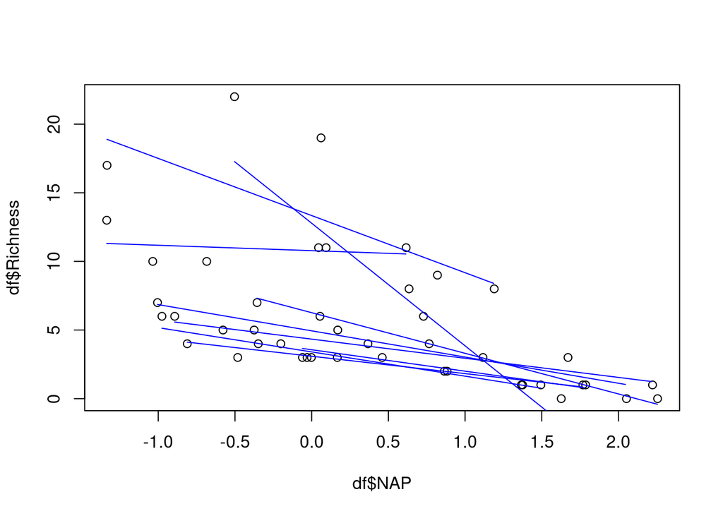

```r
plot(df$NAP, df$Richness)

for (i in 1:9){
  df.sub=subset(df, df$Beach==i)
  x.pred = seq(from=min(df.sub$NAP), to=max(df.sub$NAP), by=0.01)
  y.cred = fitted(fit.b.no, newdata=data.frame(NAP=x.pred,
                                               Beach=levels[i] ) )
  lines(x.pred, y.cred[, 1], col="blue")
}
```

# brms partial pooling

With partial pooling, we use a random intercepts and slopes for the categorical predictor `Beach`. This time, we provide priors for the “fixed effects”, i.e. mean intercept and slope.

```r
priors = c(prior(normal(5,5), class=Intercept),
           prior(normal(0,10), class=b) )
```

```r
fit.b.part = brm( Richness ~ 1+NAP + (1+NAP|Beach),
                  prior=priors,
                  data=df )
```

Now, in the population-level effects mean intercept $\mu_a$ and slope $\mu_b$ are shown. The group-level effects only contain a summary of the random effects. It’s standard deviations ($\sigma_a,\sigma_b$) and the correlation between slopes and intercepts $\text{cor}(a,b)$.

```r
fit.b.part
```

```
##  Family: gaussian
##   Links: mu = identity; sigma = identity
## Formula: Richness ~ 1 + NAP + (1 + NAP | Beach)
##    Data: df (Number of observations: 45)
##   Draws: 4 chains, each with iter = 2000; warmup = 1000; thin = 1;
##          total post-warmup draws = 4000
##
## Group-Level Effects:
## ~Beach (Number of levels: 9)
##                    Estimate Est.Error l-95% CI u-95% CI Rhat Bulk_ESS Tail_ESS
## sd(Intercept)          3.83      1.20     2.05     6.73 1.00      994     1671
## sd(NAP)                1.86      0.89     0.29     3.92 1.00     1006     1174
## cor(Intercept,NAP)    -0.62      0.34    -0.99     0.28 1.00     1951     2401
##
## Population-Level Effects:
##           Estimate Est.Error l-95% CI u-95% CI Rhat Bulk_ESS Tail_ESS
## Intercept     6.63      1.36     3.91     9.30 1.00     1208     1671
## NAP          -2.71      0.83    -4.39    -1.07 1.00     1682     2019
##
## Family Specific Parameters:
##       Estimate Est.Error l-95% CI u-95% CI Rhat Bulk_ESS Tail_ESS
## sigma     2.73      0.41     2.06     3.65 1.00     1226     2086
##
## Draws were sampled using sampling(NUTS). For each parameter, Bulk_ESS
## and Tail_ESS are effective sample size measures, and Rhat is the potential
## scale reduction factor on split chains (at convergence, Rhat = 1).
```

Again, instead of fitting all intercepts $a_j$ and slopes $b_j$ `brm()` fits the differences $\alpha_j=a_j-\mu_a$ and $\beta_j=b_j-\mu_b$. The model reads

$$\begin{align}
y_i &\sim \text{normal}((\mu_a +\alpha_{group(i)}) + (\mu_b +\beta_{group(i)})\cdot x, \sigma), \quad i=1,...,n \quad (n\ \text{observations}) \\
\alpha_j &\sim \text{normal}(0, \sigma_{a}), \quad j=1,...,m \quad (m\ \text{groups}) \\
\beta_j &\sim \text{normal}(0, \sigma_{b}), \quad j=1,...,m \quad (m\ \text{groups})
\end{align}$$

```r
ranef(fit.b.part)
```

```
## $Beach
## , , Intercept
##
##    Estimate Est.Error       Q2.5     Q97.5
## 1  2.540847  1.743882 -0.8419498 6.0209580
## 2  5.788072  1.833344  2.3432109 9.3839597
## 3 -2.804893  1.683489 -6.0873369 0.4444730
## 4 -2.926661  1.800657 -6.4835468 0.5165117
## 5  4.207380  2.045448  0.1887037 8.2839585
## 6 -2.038257  1.654506 -5.3573790 1.2476575
## 7 -2.323106  1.935573 -6.3232722 1.4981540
## 8 -1.432882  1.745339 -4.7384368 2.0101851
## 9 -0.329528  1.759999 -3.7325519 3.1625538
##
## , , NAP
##
##      Estimate Est.Error      Q2.5      Q97.5
## 1  0.14891816  1.255007 -2.074871 3.01373291
## 2 -1.51070274  1.305144 -4.210327 0.86520672
## 3  0.88227617  1.140999 -1.300154 3.30303108
## 4  1.01779069  1.179102 -1.200473 3.52142295
## 5 -3.02565058  1.833075 -6.692674 0.02281932
## 6  0.92695921  1.071852 -1.093888 3.23927093
## 7  0.67046217  1.309826 -1.895710 3.41201102
## 8  0.58224544  1.046994 -1.325798 2.73604016
## 9 -0.07492481  1.098433 -2.286378 2.17586757
```

Now, let’s look at observed and predicted. `conditional_effects()` plots fixed effects only by default. The whole dataset is shown and predictions with mean slope $\mu_b$ and mean intercept $\mu_a$.

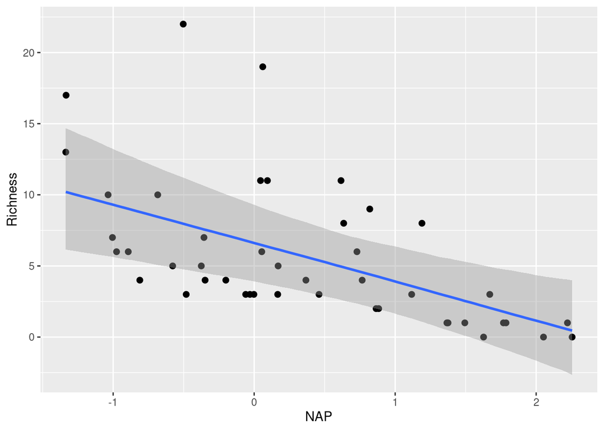

```r
plot( conditional_effects(fit.b.part),
      points=TRUE,
      ask=FALSE )
```

When specifying group-level predictors (all levels) with `conditions=`, we receive a warning that they are not part of the (fixed effects) model. We see aplot for all levels of `Beach`, but the regression line is the same: predictions for fixed effects part only!

```
## Warning: The following variables in 'conditions' are not part of the model:
## 'Beach'
```

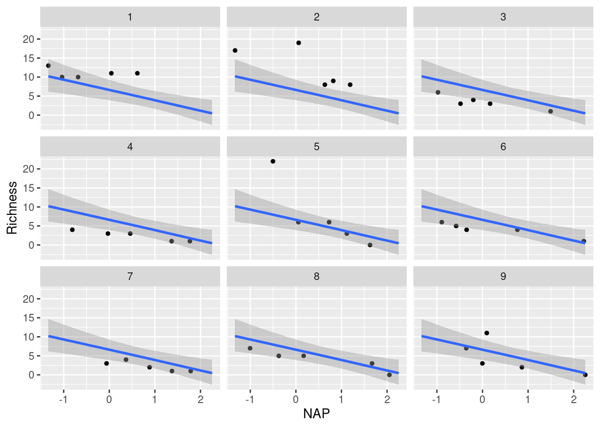

```r
plot( conditional_effects(fit.b.part,
                          effects = "NAP",
                          conditions = data.frame(Beach=levels(df$Beach)) ),
      points=TRUE,
      ask=FALSE )
```

To include also the random effects for model predictions, `re_formula=NULL` must be specified. This reads a little weird (I would have expected something like `re_formula=TRUE`), but the default for no random effects as above is `re_formula=NA` and `NULL` is the command for using random effects for prediction here.

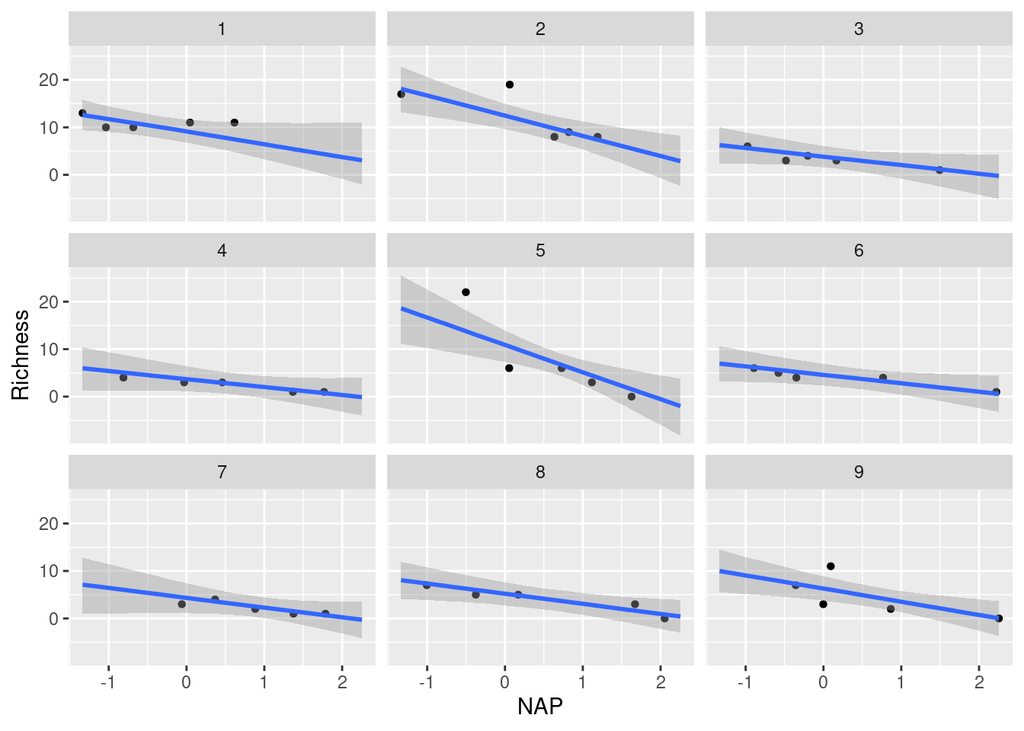

```r
plot( conditional_effects(fit.b.part,
                          effects = "NAP",
                          re_formula = NULL,
                          conditions = data.frame(Beach=levels(df$Beach)) ),
      points=TRUE,
      ask=FALSE )
```

Same as in the “no pooling” model, group-level predictions can also be extracted by hand using `fitted()`.

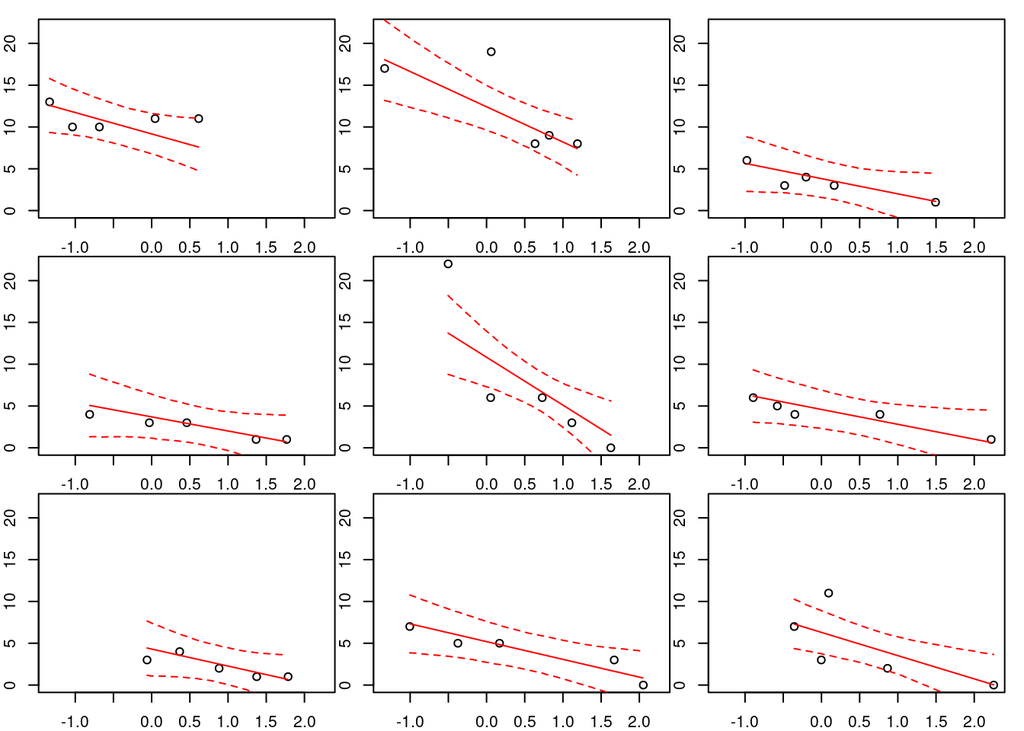

```r
levels = levels(df$Beach)

par(mfrow=c(3,3), mar=c(1,1,1,1), oma=c(1,1,0,0))
for (i in 1:9){
  df.sub=subset(df, df$Beach==i)
  x.pred = seq(from=min(df.sub$NAP), to=max(df.sub$NAP), by=0.01)
  plot(df.sub$NAP,  df.sub$Richness,
       xlim=range(df$NAP),
       ylim=range(df$Richness)  )

  y.cred = fitted(fit.b.part, newdata=data.frame(NAP=x.pred,
                                                 Beach=levels[i] ) )

  lines(x.pred, y.cred[, 1], col="red")
  lines(x.pred, y.cred[, 3], col="red", lty=2)
  lines(x.pred, y.cred[, 4], col="red", lty=2)
}
```

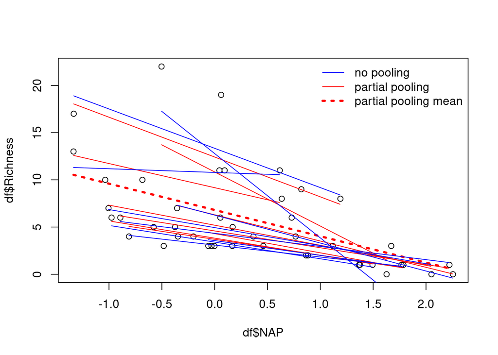

```r
plot(df$NAP, df$Richness)

# partial pooling
for (i in 1:9){
  df.sub=subset(df, df$Beach==i)
  x.pred = seq(from=min(df.sub$NAP), to=max(df.sub$NAP), by=0.01)
  y.cred = fitted(fit.b.part, newdata=data.frame(NAP=x.pred,
                                                 Beach=levels[i] ) )
  lines(x.pred, y.cred[, 1], col="red")
}

x.pred = seq(from=min(df$NAP), to=max(df$NAP), by=0.01)
y.cred = fitted(fit.b.part, newdata=data.frame(NAP=x.pred,
                                               Beach=NA) )

# partial pooling mean
lines(x.pred, y.cred[, 1], col="red", lwd=3, lty=3)

# no pooling (previous model)
for (i in 1:9){
  df.sub=subset(df, df$Beach==i)
  x.pred = seq(from=min(df.sub$NAP), to=max(df.sub$NAP), by=0.01)
  y.cred = fitted(fit.b.no, newdata=data.frame(NAP=x.pred,
                                               Beach=levels[i] ) )
  lines(x.pred, y.cred[, 1], col="blue")
}

legend("topright",
       legend=c("no pooling","partial pooling", "partial pooling mean"),
       lwd=c(1,1,3),
       lty=c(1,1,3),
       col=c("blue","red","red"),
       bty="n")
```

# Extra: GLMM

We assumed normally distributed residuals and the default in `brms` is Gaussian indeed. But the reponse we model (species richness) is an integer (not continous), it’s also non-negative. So we could use a Poisson distribution for the stochastic part of the model, which is standard practice for count data. By specifying `family=poisson`, also a log-link is chosen by default. This means the regression lines become an exponential functions, which are non-negative, too.

```r
fit.b.GLMM = brm( Richness ~ 1+NAP + (1+NAP|Beach),
                  family=poisson,
                  data=df )
```

```r
fit.b.GLMM
```

```
##  Family: poisson
##   Links: mu = log
## Formula: Richness ~ 1 + NAP + (1 + NAP | Beach)
##    Data: df (Number of observations: 45)
##   Draws: 4 chains, each with iter = 2000; warmup = 1000; thin = 1;
##          total post-warmup draws = 4000
##
## Group-Level Effects:
## ~Beach (Number of levels: 9)
##                    Estimate Est.Error l-95% CI u-95% CI Rhat Bulk_ESS Tail_ESS
## sd(Intercept)          0.70      0.24     0.38     1.29 1.00     1315     2129
## sd(NAP)                0.45      0.22     0.14     0.98 1.00      908      906
## cor(Intercept,NAP)     0.11      0.39    -0.67     0.81 1.00     2094     2171
##
## Population-Level Effects:
##           Estimate Est.Error l-95% CI u-95% CI Rhat Bulk_ESS Tail_ESS
## Intercept     1.68      0.26     1.16     2.18 1.00     1203     1597
## NAP          -0.62      0.20    -1.03    -0.24 1.01     1236      851
##
## Draws were sampled using sampling(NUTS). For each parameter, Bulk_ESS
## and Tail_ESS are effective sample size measures, and Rhat is the potential
## scale reduction factor on split chains (at convergence, Rhat = 1).
```

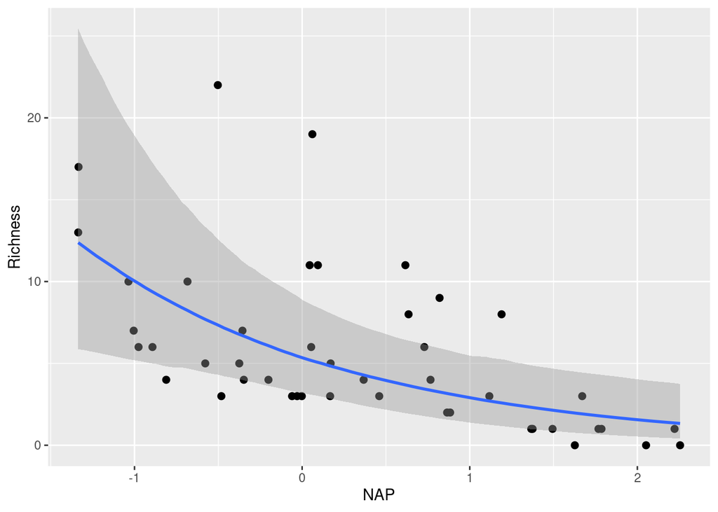

```r
plot( conditional_effects(fit.b.GLMM),
      points=TRUE,
      ask=FALSE )
```

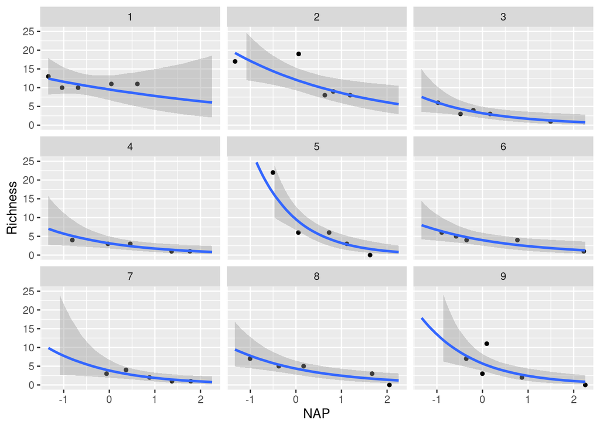

```r
p = plot( conditional_effects(fit.b.GLMM,
                              effects = "NAP",
                              re_formula = NULL,
                              conditions = data.frame(Beach=levels(df$Beach)) ),
          points=TRUE,
          ask=FALSE,
          plot=FALSE)
p[[1]] + ggplot2::ylim(c(0,25))
```